# Modelos no Supervisados

Sebastian Jaremczuk

2020-04-17

### 0.0.1 carga de datos

### 0.0.2 Reducción de Dimensión

#### 0.0.2.1 Análisis de Componentes Principales

Se aplica a técnica de Componentes Principales para reducir las variables predictoras pero que tengan un gran porcentaje de la variabilidad total.

```
Setting row names on a tibble is deprecated.
```

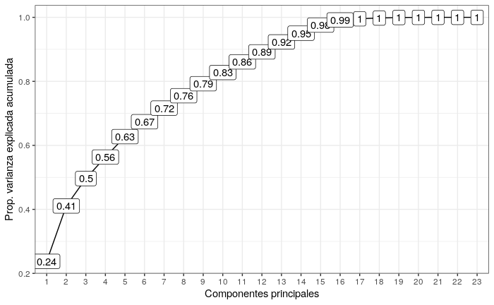

Loadings de PCA en Tablon

| variable | PC1 | PC2 | PC3 | PC4 |
| --- | --- | --- | --- | --- |
| Turno_Manana | 0.2813063 | -0.1375132 | 0.0171629 | 0.0891187 |
| tipo_de_aprobacion_libre | -0.0516192 | -0.2204644 | -0.1151088 | -0.3721061 |
| tipo_de_aprobacion_cambio_curso | 0.0985927 | -0.0960438 | 0.0259816 | -0.0003118 |
| tipo_de_aprobacion_promociono | 0.3581733 | 0.1308245 | -0.0808955 | 0.0804953 |
| edad_al_ingreso | -0.1269356 | 0.0733137 | -0.2349852 | -0.2976394 |
| tipo_de_aprobacion_no_firmo | 0.0156176 | -0.4488391 | -0.1126781 | -0.1126948 |
| ciclo_lectivo_de_cursada | 0.1818683 | -0.0532719 | -0.1144249 | -0.0532596 |
| tipo_de_aprobacion_firmo | 0.3996032 | 0.0206986 | 0.0690403 | -0.0132481 |
| cant_resursada_regular | 0.0227835 | -0.3127946 | -0.4101361 | 0.3674317 |
| cant_recursada_regular_No_Recurso | 0.3869691 | 0.1219610 | 0.0468956 | 0.0352279 |
| cant_recursada_regular_Recurso1vez | 0.1188652 | -0.2681558 | 0.0654967 | -0.1891977 |
| cant_recursada_regular_Recurso2vez | 0.0451665 | -0.2939066 | -0.0071695 | -0.1971879 |
| cant_recursada_regular_Recurso3vez | 0.0120116 | -0.2503402 | -0.0867234 | -0.1612458 |
| cant_recursada_regular_Recurso4vez | 0.0044083 | -0.1971933 | -0.0845225 | -0.1281708 |
| cant_recursada_regular_Recurso5vez | 0.0006389 | -0.1464459 | -0.1411299 | 0.0048529 |
| cant_recursada_regular_RecursoNveces | -0.0021967 | -0.1955233 | -0.4257671 | 0.4879239 |
| Turno_Tarde | 0.1153361 | -0.1754377 | 0.0127343 | 0.0859205 |
| Turno_Noche | 0.2032766 | -0.1098708 | -0.0798642 | -0.3755512 |
| Aprobado | 0.3918783 | 0.1006967 | -0.0242947 | -0.0374767 |
| Promociono | 0.3589365 | 0.1289055 | -0.0812155 | 0.0798013 |
| noAprobado | 0.2504186 | -0.1806504 | 0.2037648 | -0.0519875 |
| Nota | -0.0001346 | 0.3003970 | -0.4732939 | -0.2012817 |
| Nota_max_prom | 0.0688392 | 0.2670847 | -0.4728596 | -0.2279385 |

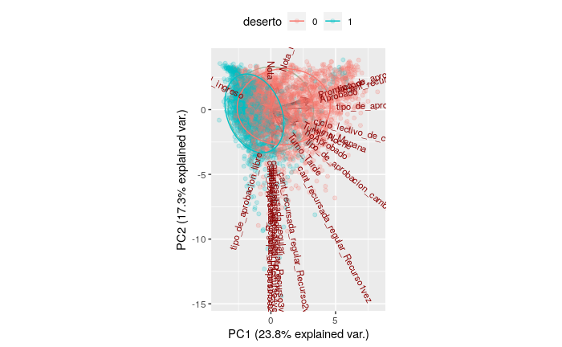

Se puede observar que si bien se puede reducir la cantidad de variables predictoras y mantener una alta variabilidad de la información explicada, los diagramas de biplot en este caso no nos servirían de mucha ayuda ya que en las primeras 2 componentes solo se explica el 41% y en las primeras 4 componentes solo el 56%. Además, los loadings de dichos componentes no tienen una clara identificación de la proyección que quieren significar, por lo que sería complicado explicar el modelo que se queira desarrollar según estas nuevas variables.

#### 0.0.2.2 Reducción por t-SNE

Al igual que PCA, existen otro algoritmos que pueden realizar ruducción de dimensionalidad. Unos de esos casos es el método no lineal t-distributed stochastic neighbor embedding (t-SNE), que en ciertos casos es ventajoso respecto a PCA que aplica reducción pero utilizando combinaciones lineales de las variables originales.

```
Ignoring unknown aesthetics: text
```

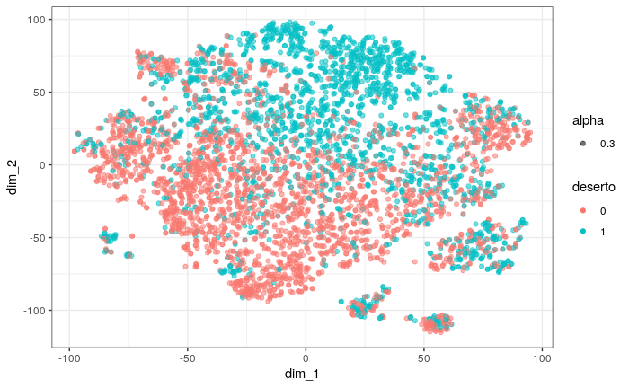

Utilizando el método T-SNE, si bien no se arman grupos bien definidos, al identificar cada observación con un color en el gráfico según el target puede observarse que están mas separadas y hay menos solapamiento entre ellas que con el método PCA. Este resultado puede insinuar que es posible clasificar un gran porcentaje de los casos correctamente.

#### 0.0.2.3 Clusters

Se utilizarán técnicas de clusters sobre la base del tablón y las reducciones de dimensión calculadas anteriormente.

Criterio: * Como son solamente 2 las variables categóricas (EsTecnico y sexo), en vez de calcular las distancias numéricas por un lado (euclídea, manhattan, correlación, etc), las distancias categóricas por otras (SMC, Jaccard, etc) y tratar de transformar esas matrices de distancias en una nueva matriz unificada con criterios, se decide transformar los datos categóricos en numéricos aprovechndo que ambos campos tiene solamente 2 valores por lo que estarán en los extremos tomando una normalización entre 0 y 1. En el caso de las observaciones que con valor nulo en la variable EsTecnico, se imputará con el valor 0.5 (mitad entre extremos)

```
Setting row names on a tibble is deprecated.
```

```
[1] 0.8893004
```

El estadístico de Hopkins sobre el tablon orifginal transformado las 2 variable cateóricas en numéricas da 0.8893004. Es un valor cercano a 1 por lo que tiene mucha tendencia a ser clusterizado.

#### 0.0.2.5 Estudio del número óptimo de clusters

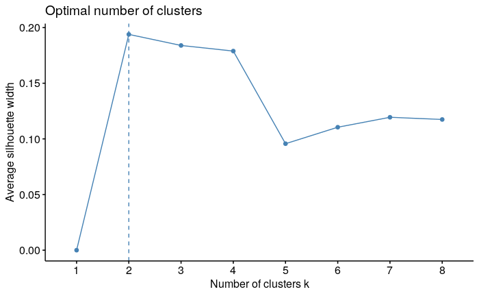

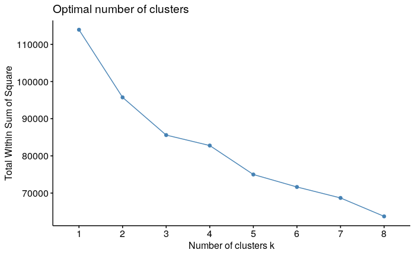

Verificación de las funciones anteriores de número óptio de clsuters pero calculadas manualmente

```
Clustering Methods:
 kmeans hierarchical

Cluster sizes:
 2 3 4 5

Validation Measures:
                                   2         3         4         5

kmeans       Connectivity     0.0000    3.1667  730.2742 1316.3881
             Dunn             0.4693    0.5735    0.0471    0.0345
             Silhouette       0.5937    0.5336    0.2070    0.1796
hierarchical Connectivity     3.1667    3.1667    9.2357   12.1647
             Dunn             0.5713    0.5735    0.2744    0.2744
             Silhouette       0.7329    0.5336    0.5198    0.4879

Optimal Scores:
```

|  | Score | Method | Clusters |
| --- | --- | --- | --- |
| Connectivity | 0.0000 | kmeans | 2 |
| Dunn | 0.5735 | kmeans | 3 |
| Silhouette | 0.7329 | hierarchical | 2 |

```
NA
```

La conslución que podes sacar es que pareciera ser que la mejor solución es hacer clusters de 2 grupos ya sea por el método Kmeans o Jerárquico.

#### 0.0.2.6 Cluster Kmeans

Tomando como referencia las validaciones anteriores, se realizará un cluster kmeans con 2 centroides. Este método se repetirá 25 veces distintas se elegirá el mejor.

|  | cluster | size | ave.sil.width |
| --- | --- | --- | --- |
| 1 | 1 | 1275 | 0.19 |
| 2 | 2 | 3283 | 0.20 |

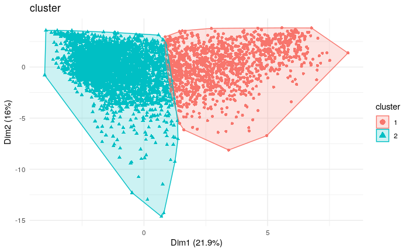

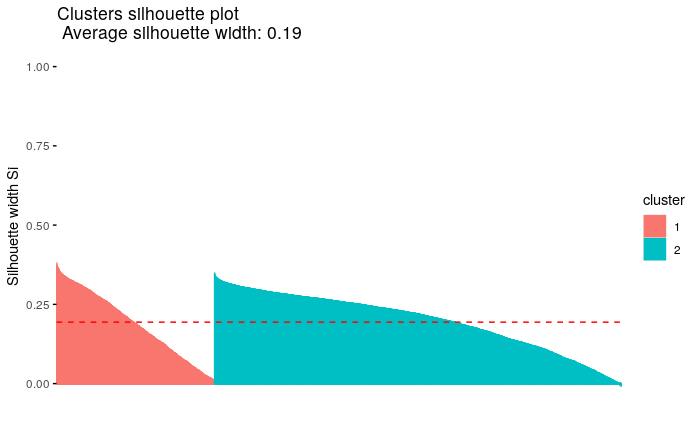

Resumen composición de cluster Kmeans según clase desertor

[output not shown]

```
Ignoring unknown parameters: alph
```

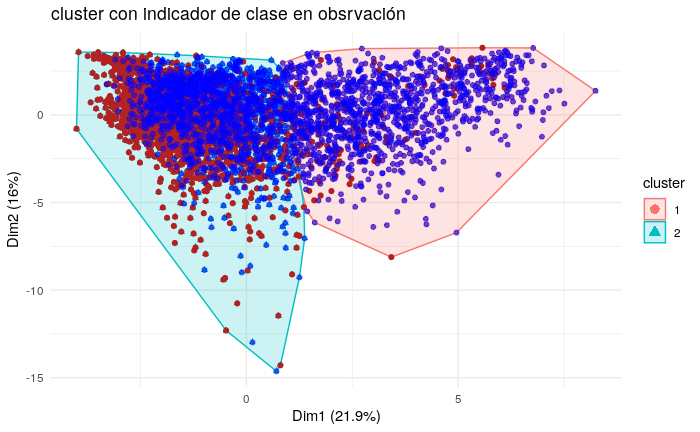

Puede observarse que un grupo contiene solamente un 11,13% de datos erroneos, pero el otro grupo està muy balanceado. Por lo tanto, el cluster de 2 grupos a pesar de que tenga muy buenos valores en las validaciones realizadas, al verificar con el target real donde queda cada obsevación no es un buen resultado. En el gráfico se observa lo expresado en la tabla.

#### 0.0.2.7 cluster jerárquico

Siguiendo lo sugerido se realiza el cluster jerárquico. Es de destacar que esta vez no puede mostrarse el dendograma completo ya que la cantidad de observaciones son muchas. Por lo cual, según lo sugerido en las validaciones, se hará el cote en 2 grupos y se verificará según la clase si la composición de los grupos se relaciona bien con e target.

Se realizan 4 cluster jerarquicos, cada uno utilizando las medidas de distancias “complete”, “average”, “single”, “ward”.

Coef. cophenetic por cada tipo de cluster jerárquico

| metodo | coeficiente_cofenetico |
| --- | --- |
| complete | 0.7199776 |
| average | 0.8142721 |
| single | 0.7217462 |
| ward | 0.3765082 |

El tipo de distancia del cluster jerárquico que arroja el mayor coeficiente cophenetico es “average” con un valor de 0.8142721.

```
Column `codigo.alumno` joining factor and character vector, coercing into character vector
```

Composición de clusters según la clase deserto

| grupo | cant_integrantes | cant_desertores | cant_desertores_pct | cant_no_desertores | cant_no_desertores_pct |
| --- | --- | --- | --- | --- | --- |
| 1 | 4550 | 1996 | 43.86813 | 2554 | 56.13187 |
| 2 | 8 | 4 | 50.00000 | 4 | 50.00000 |

se puede observar que forma un grupo muy numeroso y otro muy chico y ambos estan muy mezclados en función el target. Por lo tanto, el método jerárquico no es adecuado.

#### 0.0.2.8 Extensión de Clusters

A pesar del estudio de validaciones y resultados anteriormente, igualmente queremos ver cuales son los resultados que nos arrojan hacer mas de 2 clusters. Como los resultados los referenciamos al target, campo que no se incluye en los datos para ahcer cluster al ser no supervisado, podría darse el caso de que en la situación real otro número de cluster sea óptima a la que arrojan las validaciones matemáticas.

[output not shown]

Resumen por tipo de cluster, cantidad de clusters y la composición de cada uno según la clase deserto

| metodo | numero_clusters | 1_N | 1_S | 2_N | 2_S | 3_N | 3_S | 4_N | 4_S | 5_N | 5_S |
| --- | --- | --- | --- | --- | --- | --- | --- | --- | --- | --- | --- |
| jerarquico | 2 | 2554 | 1996 | 4 | 4 | NA | NA | NA | NA | NA | NA |
| jerarquico | 3 | 2544 | 1972 | 10 | 24 | 4 | 4 | NA | NA | NA | NA |
| jerarquico | 4 | 2544 | 1970 | NA | 2 | 10 | 24 | 4 | 4 | NA | NA |
| jerarquico | 5 | 2543 | 1970 | NA | 2 | 10 | 24 | 1 | NA | 4 | 4 |
| kmeans | 2 | 1133 | 142 | 1425 | 1858 | NA | NA | NA | NA | NA | NA |
| kmeans | 3 | 878 | 82 | 611 | 604 | 1069 | 1314 | NA | NA | NA | NA |
| kmeans | 4 | 1028 | 1252 | 842 | 73 | 14 | 28 | 674 | 647 | NA | NA |
| kmeans | 5 | 725 | 576 | 400 | 837 | 606 | 487 | 14 | 28 | 813 | 72 |

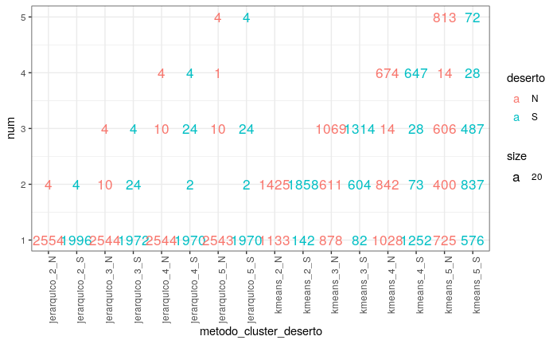

La figura muestra la misma información que el cuadro anterior. En el eje x indica que tipo de cluster es, cuantos clusters y la clase deserto (“S” y “N”). En el eje y se indica el numero de cluster, por lo que los cluster armados solo con 2 clusters, habrá información únicamente hasta esa altura. Por ejemplo, para el el caso de aplciar un método jerárquico de 2 clusters podemos observar que en el primer cluster tenemos 2554 casos Negatigos y 1996 casos positivos, mientras que el cluster número 2 esta conformado de 4 casos negativos y 4 casos positivos.